# Fundamentos de la actividad empresarial

Para realizar mejor el trabajo diario, es importante conocer qué actividades se llevan a cabo en toda la empresa.

- Comprensión de productos y servicios.
- Comprensión de la calidad integral.
- Comprensión de Ho-Ren-So: 5W1H.
- Comprensión del principio de las 3Gs y las 5Gs.
- Comprensión de las 5S.
- Comprensión de seguridad, salud y regulaciones.

[Audio_1](https://drive.google.com/file/d/1MN0zLm089HKl5OV0UapK-oZ1GOKQOvW4/view?usp=drive_link)

```python
import os

try:
  os.chdir('../Python/QCKentei4')
except:
  pass

path = os.getcwd()
path
```

```
'/Users/takanohiroshi/Library/CloudStorage/OneDrive-個人用/Documenten/Python/QCKentei4'
```

```python
from PIL import Image
```

## 09-01 Productos y Servicios

製品とサービス

Un producto es aquello que se ofrece a los clientes como resultado de las actividades de una empresa, por lo clientes encuentran valor y pagan un precio. Dentro de los productos también se incluyen los servicios intangibles.

[Audio_2](https://drive.google.com/file/d/1QSbMK1g2dNgdZVlvgj102oq-2VZ3jlkh/view?usp=drive_link)

## 09-02 Calidad total en el lugar de trabajo

Calidad integral en el ámbito laboral / Calidad global en el entorno de trabajo. 職場における総合的な品質

### 1. Calidad total

calidad integral / Calidad global 総合的な品質

#### (1) QCD

**QCD** son las siglas de

- Quality (Calidad),
- Cost (Costo),
- Delivery (Entrega/Plazo/Cantidad),

aspectos particularmente importantes al considerar productos y servicios. Estos tres elementos se conocen como calidad total.

#### (2) PSME

**PSME** son las siglas de

- Productivity (Productividad),
- Safety (Seguridad),
- Morale (Moral/Ánimo/Motivación), Moral (Ética),
- Environment (Medio Ambiente),

aspectos importantes en el lugar de trabajo donde se producen bienes y servicios.

[Audio_3](https://drive.google.com/file/d/12zbEVYMrGJCr7sAmrshAVVKHW_XRKsfh/view?usp=drive_link)

## 09-03 Ho-Ren-So

報告・連絡・相談（ほうれんそう）

Horenso es una crónimo de Hokoku (Informe), Renraku (Comunicación) y Sodan (Consulta), elementos necesarios para que el trabajo se desarrolle sin problemas.

- Hokoku 報告: Es comunicar la información necesaria a superiores o clientes en respuesta a una instrucción, orden o solicitud.
- Renraku 連絡: Es transmitir de forma proactiva la información necesaria a las personas, departamentos u organizaciones pertinentes.
- Sodan 相談: Es solicitar la opinión de personas con capacidad de decisión sobre asuntos que uno mismo no puede resolver.

[Audio_4](https://drive.google.com/file/d/1O1Hg86gwnF6ySKmqIdF4WAifiKEQZbAL/view?usp=drive_link)

## 09-04 5W1H

5W1H es un método de pensamiento utilizado para analizar y comunicar ideas, acciones, entornos, etc.

- What (Qué): Qué
- When (Cuándo): Cuándo
- Who (Quién): Quién
- Where (Dónde): Dónde
- Why (Por qué): Por qué
- How (Cómo): Cómo

[Audio_5](https://drive.google.com/file/d/13VrjN2fabBfNUJQ4jptXJup9V2O7dTnT/view?usp=drive_link)

## 09-05 Pricipio de los tres Gen / cinco Gen

三現主義・５ゲン主義

### 1. Principio de los tres Gen

三現主義

La filosofía de las Tres Realidades (3-Gen Shugi) es la idea de que, al resolver problemas o realizar actividades de mejora, es crucial actual desde las perspectivas del lugar real (Genba), el objeto real (Genbutsu), y la situación real (Genjitsu).

- Genba （現場）: El lugar real (donde ocurre el trabajo o el problema)
- Genbutsu （現物）: El objeto real (el producto, la pieza, etc.)
- Genjitsu （現実）: La cituación real (los hechos y datos concretos).

### 2. Principio de los cinco Gen

５ゲン主義

La filosofía de las Cinco Realidades (5-Gen Shugi) es la idea de que, para descubrir la causa raíz de un problema y realizar actividades de mejora más efectivas, es crucial adoptar cinco perspectivas: las tres de la filosofía de las Tres Realidades (lugar real, objeto real, situación real), a las que se añaden el principio (Genri) y el precepto (Gensoku).

- Genri 原理: El principio (la teoría o la causa fundamental)
- Gensoku 原則: La regla (la norma o el estándar)

[Audio_6](https://drive.google.com/file/d/18Lddq3HZ_84Hqh8BVXIzlplZRgyu2h_5/view?usp=drive_link)

## 09-06 Modales en la vida empresarial

企業生活のマナー

Los modales son los entendimientos tácitos y las reglas no explícitas que se deben observar en las relaciones laborales y al llevar a cabo el trabajo.

- Compromiso como profesional / Mentalidad profesional
- Puntualidad
- Saludo proactivo / Saludar con iniciativa
- Uso de un lenguaje cortés
- Vestimenta apropiada
- Separación entre lo publica y lo privado / Separar la vida personal de la profesional
- Organización y orden
- Cuidado del medio ambiente / Concienciación ambiental

[Audio_7](https://drive.google.com/file/d/1_jTDbtfi7vmF5i-JLmS9d62Z-NVC7LH0/view?usp=drive_link)

## 09-07 5S

整理、整頓、清掃、清潔、躾

Las 5S son cinco acciones consideradas fundamentales para el mantenimiento del entorno de trabajo y la forma de abordar el trabajo, y son las iniciales de

- Seiri (Clasificación/Organización),
- Seiton (Orden),
- Seiso (Limpieza),
- Seiketsu (Estandarización/Higiene) y
- Shitsuke (Disciplina/Mantenimiento).

[Audio_8](https://drive.google.com/file/d/1O6Rps3LvJFTrjzVHly48x0nDmNmWC5UG/view?usp=drive_link)

## 09-08 Seguridad e higiene

Seguridad y salud laboral 安全衛生

### 1. Seguridad y salud en el trabajo

Seguridad y salud laboral 労働安全衛生

Seguridad y salud laboral se refiere a garantizar la seguridad y la salud de los trabajadores en el lugar de trabajo, así como a crear un ambiente de trabajo confortable.

### (1) Actividad KY (Kiken Yochi - Predicción de Peligros)

KY（危険予知）活動

Actividad de predicción de riesgos / Análisis de riesgos preventivo.

La Actividad KY (Predicción de Peligros) es una actividad que se lleva a cabo en el lugar de trabajo antes de comenzar una tarea, con el objetivo de identificar de antemano las acciones peligrosas. Es un acrónimo de Kieken (Peligro) y Yochi (Predicción).

### (2) La ley de Heinrich y la actividad e Hiyari-Hatto (Casi-Accidente)

ハインリッヒの法則とヒヤリ・ハット活動

La ley de Heinrich es un principio que establece que por cada accidente o lesión grave, hay 29 accidentes o lesiones leves, a su vez, detrás de estos hay 300 incidentes sin lesiones (casi accidentes o Hiyari-Hatto).

[Audio_9](https://drive.google.com/file/d/1HMmb2NdCIiebOBxSwh_h1ZU0yoJHMIeD/view?usp=drive_link)

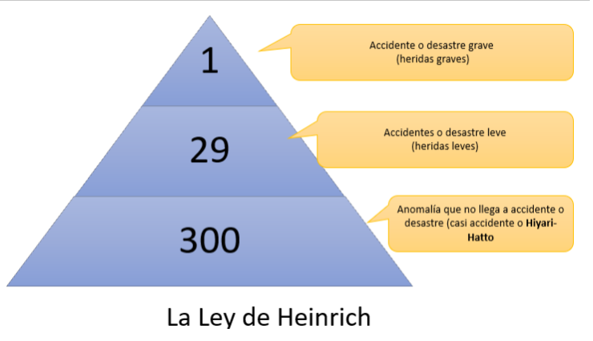

```python
img = Image.open('./Data4/LayDeHeinrich.png')
display(img)
```

## 09-09 Reglas y Estándares

規則と基準

Las reglas son asuntos que deben cumplirse y que están definidos o documentados.

Los estándares son acuerdos establecidos por la industria o por organizaciones como las empresas. A través de los estándares, las cosas se simplifican y se unifican en diversas situaciones y entre diferentes usuarios.

[Audio_10](https://drive.google.com/file/d/1qA36rjgV2cfKsdrLhBrXWdZJEpRbJ-du/view?usp=drive_link)

```python
notebook_name = 'QCKentei4-9.ipynb'
notebook_name_html = notebook_name.replace(".ipynb",".html")

!jupyter nbconvert --to html {notebook_name}
```

```
[NbConvertApp] Converting notebook QCKentei4-9.ipynb to html
[NbConvertApp] Writing 695971 bytes to QCKentei4-9.html
```